# Extramedullary_hematopoiesis

Junyao Jiang

2026-01-21

This page offers descriptions and download links for all well-processed sequencing data from the Extramedullary hematopoiesis paper.

# Download link

https://westlakeu-my.sharepoint.com/:f:/g/personal/jiangjunyao_westlake_edu_cn/IgD0TFy2n4XYTa6_DrQi-uuGAUYcBrGWNdPcMOQMC9VbgKA

# Data descriptions

## Experiment 1: Bulk lineage tracing (Figure1-2)

**Bulk lineage tracing.rds**: This dataset consists of bulk DNA sequencing of Polylox barcodes from FACS-isolated HSPCs across bone marrow, spleen, and liver, generated from *Hlf<sup>CreER</sup>Rosa26<sup>Polylox</sup>* mice induced at E17.5 and adult (7 weeks) stages to map developmental origins (Figure 1). It also includes barcode sequencing of HSCs and MPPs isolated from the bone marrow and spleen of pregnant (E12.5) and control mice (induced at 6 weeks) to determine clonal architecture and tissue residency under physiological stress (Figure 2).

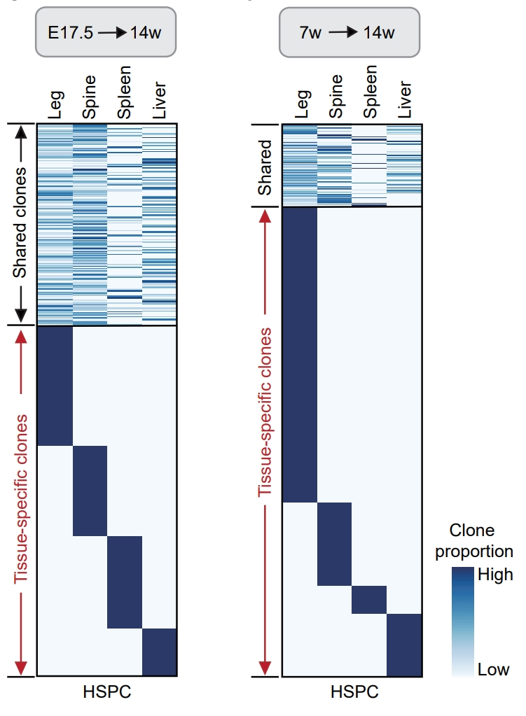

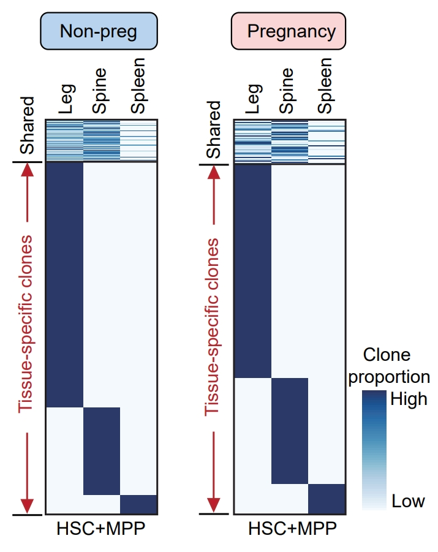

## Experiment 2: Bulk RNA-seq (Figure3)

**Bulk RNA-seq.csv**: This dataset contains transcriptional profiles generated via bulk RNA sequencing of FACS-isolated HSCs from paired bone marrow and spleen samples obtained from pregnant (E12.5) and non-pregnant control mice.

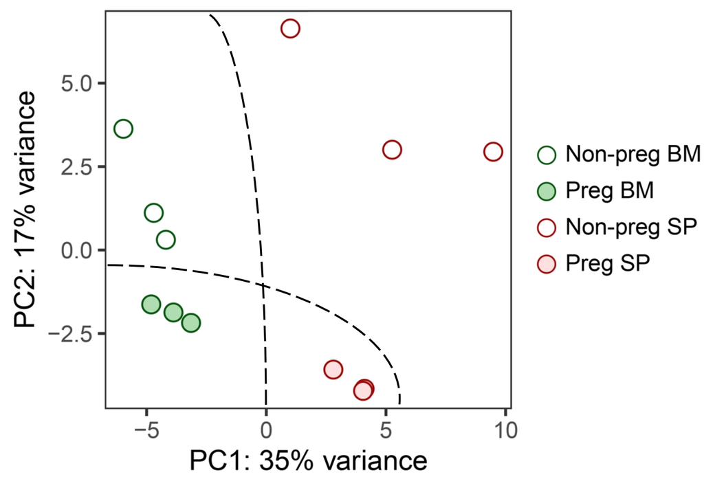

## Experiment 3: stereo-seq (Extended Data Figure 6)

**spleen spatial.h5ad**: This dataset contains high-resolution Stereo-seq spatial transcriptomic profiles of whole mouse spleen sections from non-pregnant and pregnant mice, covering major splenic regions and associated erythrocyte-related transcriptional signals.

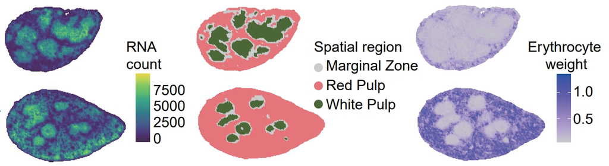

## Experiment 4: scRNA-seq (Extended Data Figure 8)

**scRNA niche.h5ad**: This dataset comprises single-cell RNA sequencing profiles of FACS-isolated niche populations—endothelial, stromal, and hematopoietic cells—from the bone marrow and spleen of pregnant and control mice. It includes a total of 19,617 cells (9,003 from bone marrow and 10,614 from spleen) across 13 distinct cell types.

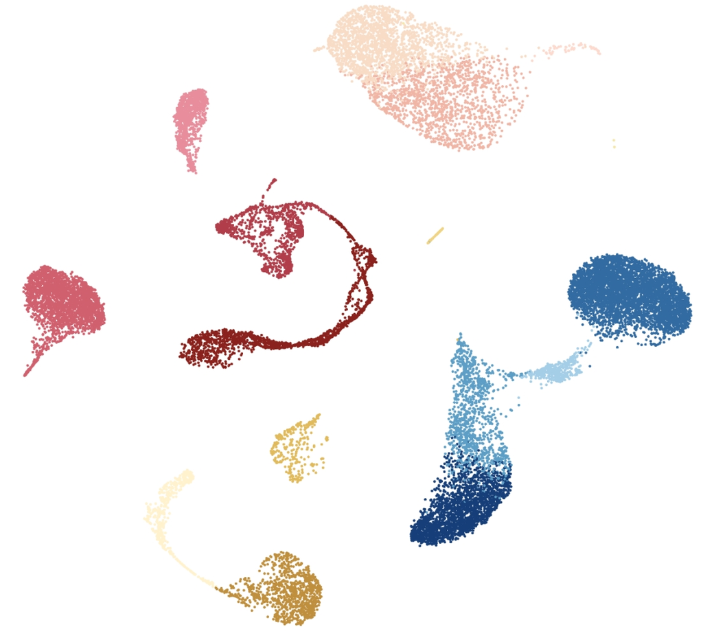

[interactive chart not shown]